# test_kidney

Feiyang ZHANG

2023-04-05

# 1 Load data

data source:

[Kidney single cell data](https://pubmed.ncbi.nlm.nih.gov/33444290/)

```r
load("./in/kidney/sc_kidney.Rdata")
Idents(sc_kidney) %>% table()
```

```
## .
##            proximal convoluted tubule          renal beta-intercalated cell
##                                  7379                                   498
## thick ascending limb of loop of Henle              proximal straight tubule
##                                  1998                                  1247
##              distal convoluted tubule              kidney interstitial cell
##                                  1416                                   471
##                      endothelial cell               renal connecting tubule
##                                   523                                  1496
##         renal alpha-intercalated cell                  renal principal cell
##                                   319                                   484
##                kidney epithelial cell   glomerular visceral epithelial cell
##                                   222                                    41
##                    kidney tubule cell
##                                    25
```

# 2 Run Time Test

## 2.1 starTracer Running Time Test

### visualization

we use dotplot to show the marker genes found by starTracer.

```r
out.Start.kidney <- starTracer::searchMarker(sc_kidney,thresh.1 = 0.5,thresh.2 = 0.3,method = "del_MI",num = 3,gene.use = "HVG")
```

[output not shown]

```
## using HVG as input features...
```

```
## max normalizing the matirx...
```

```
## screen genes in each cluster according to thresh.2
```

```
## calculating parameters...
```

```
## Using "RNA" as the assay to plot Heatmap...
```

```
## createing out put data...
```

```
## Analysing Complete!
```

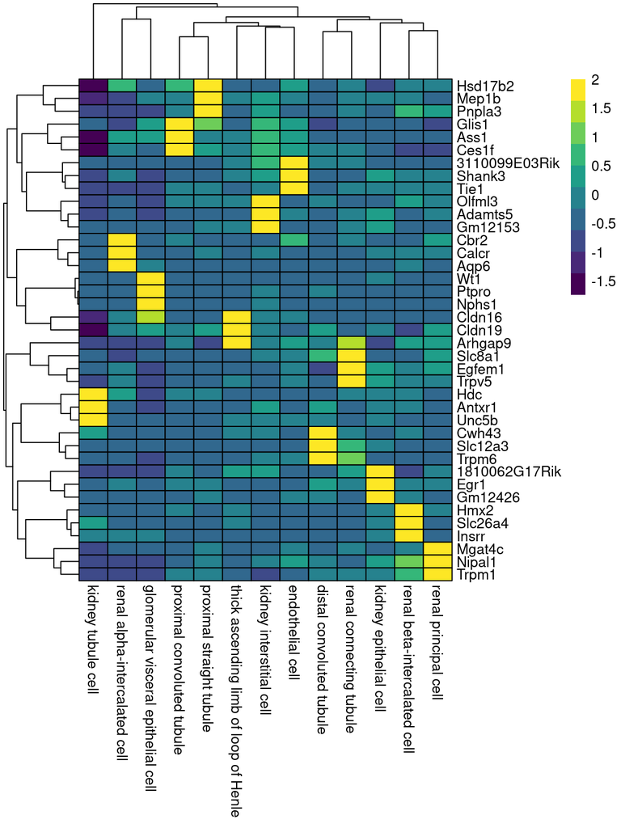

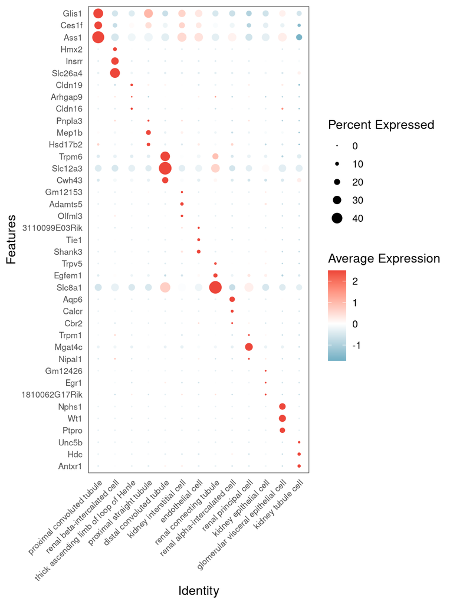

```r
(p <- use_dotplot(sc_kidney,features = out.Start.kidney$genes.markers, colors.gradient = c("#018daa","#ffffff","#ed463a")))
```

## 2.2 Seurat Running Time Test

We test the run time 10 times. The 11th time’s result will be stored.

```r
t.Seurat <- c()
for(i in 1:11){
  if(i <= 10){
    print(paste0("calculating time:",i))
    t1 <- Sys.time()
    FindAllMarkers(sc_kidney,logfc.threshold = 0.5,only.pos = T)
    t2 <- Sys.time()
    t <- t2-t1 #10.99338/10.1306 secs 12.34614/12.43914/11.35643 for HVG
    t.Seurat <- append(t.Seurat,t)
  } else {
    out.kidney.Seurat <- FindAllMarkers(sc_kidney,logfc.threshold = 0.5,only.pos = T)
  }
}
```

load

```r
load("./out/f3_kidney/t.Seurat.kidney.Rdata") #name: t.Seurat.kidney
load("./out/f3_kidney/markers.Seurat.Rdata") #name: out.kidney.Seurat
```

The calculation time:

```r
t.Seurat.kidney
```

```
## Time differences in secs
##  [1] 46.14564 45.64366 44.98694 45.12856 45.50490 45.14492 45.29713 45.11942
##  [9] 44.98471 45.39781
```

```r
t.Star.kidney
```

```
## Time differences in secs
##  [1] 1.345816 1.382693 1.674973 1.387419 1.350904 1.707497 1.661734 1.325238
##  [9] 1.335442 1.342595
```

## 2.3 Difference of calculation time of Seurat and starTracer

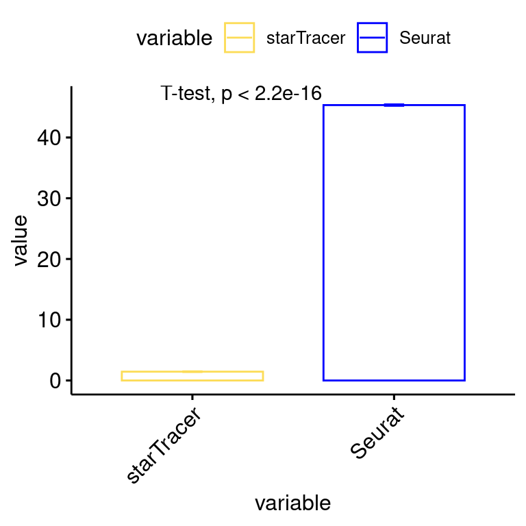

```r
time.1 <- as.numeric(t.Seurat.kidney)
time.2 <- as.numeric(t.Star.kidney)
frame.time <- data.frame(starTracer = time.2, Seurat = time.1)
frame.time$RunTime <- 1:10 %>% as.vector()
mat.use <- reshape2::melt(frame.time,id = "RunTime")
(p <- ggbarplot(mat.use, x = "variable", y = "value", add = c("mean_se"),color = "variable",fill = "white",palette = c("#fcdc57","blue"),stat = "identity",
          position = position_dodge(0.8)) + stat_compare_means(method = "t.test") + theme(axis.text.x = element_text(angle = 45,hjust = 1)))
```

show the results:

```r
(fc <- mean(time.1)/mean(time.2))
```

```
## [1] 31.23494
```

# 3 Specificity

## 3.1 Specificity of the Top5 marker genes of starTracer

### Calculate the top5 marker genes for Ti calculation

Same as previous chapters, we will find the top 5 marker genes for specificity test. Specificity is defined as:

$$T_i=\frac{\mathrm{card}\ \left(\mathrm{G}_\mathrm{i}\mathrm{\cap}\
\mathrm{G}_{\mathrm{clust}}\right)}{\mathrm{card}\left(\mathrm{G}_\mathrm{i}\right)}$$

Where:

Gi represents the set of the cells expressing gene i *in-silico*.

Gclust represents the set of cells where gene i serves as the *in-silico* marker gene.

Please refer to our original research article to see more details.

[output not shown]

```
## using HVG as input features...
```

```
## max normalizing the matirx...
```

```
## screen genes in each cluster according to thresh.2
```

```
## calculating parameters...
```

```
## Using "RNA" as the assay to plot Heatmap...
```

```
## createing out put data...
```

```
## Analysing Complete!
```

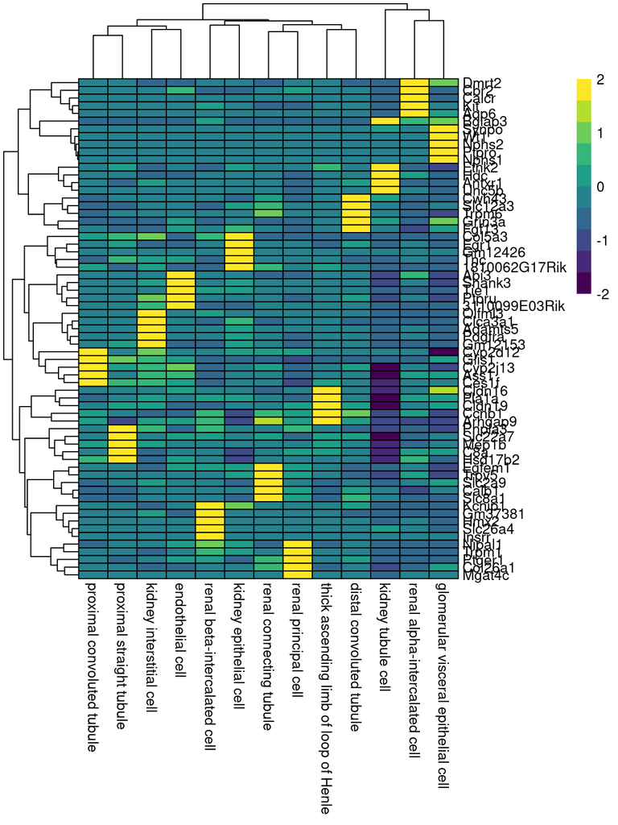

### Calculate specificity measured by Ti

calculating specificity level defined by Ti might be time consuming especially for large data set. Ti is calculated by function `cal_spe`. Please refer to “`function.R`” for more details.

```r
frame.star <- subset(out.Start.kidney.5$para_frame,out.Start.kidney.5$para_frame$gene %in% out.Start.kidney.5$genes.markers)[,c("max.X","gene")]
colnames(frame.star)[1] <- "cluster"

#Idents(snRNA.hpfc.sct)

frame.star <- cal_spe(sc_kidney,ident.use = "cell_type__ontology_label",frame.star)
frame.star %>% head()
```

```
##                              cluster    gene   pct.pos
## Glis1     proximal convoluted tubule   Glis1 0.7881795
## Ces1f     proximal convoluted tubule   Ces1f 0.7004859
## Ass1      proximal convoluted tubule    Ass1 0.7523093
## Cyp2d12   proximal convoluted tubule Cyp2d12 0.7763566
## Cyp2j13   proximal convoluted tubule Cyp2j13 0.7847332
## Hmx2    renal beta-intercalated cell    Hmx2 0.8248588
```

## 3.2 Frame of Seurat

Generating the frame of Seurat is the same as before:

1. Find marker genes using FindAllMarkers function.
2. Subset the matrix by setting p-value < 0.05
3. re-arrange the data.frame by cluster and descending average log2(Fold-Change)
4. Keep the top 10 marker gene in each cluster

```r
gene.seurat <- subset(out.kidney.Seurat,out.kidney.Seurat$p_val_adj < 0.05)
gene.seurat <- arrange(gene.seurat,cluster,desc(avg_log2FC))
gene.seurat <- with(gene.seurat,by(gene.seurat[,"gene"],INDICES = cluster,FUN = function(x)head(x,10))) %>% unlist() %>% as.vector() %>% rev()

gene.seurat %>% head()
```

```
## [1] "Snap91"        "Lrrtm4"        "Gm13528"       "Pemt"
## [5] "RP23-205F19.4" "Ppp1r14b"
```

We then re-arrange the marker gene data.frame. As for the genes that occurs in more than one cluster, we will only keep it in the cluster that has larger avg_log2FC.

```r
frame.seurat <- out.kidney.Seurat[,c("cluster","gene","avg_log2FC")] %>% subset(out.kidney.Seurat$gene %in% gene.seurat)
frame.seurat <- arrange(frame.seurat,gene,desc(avg_log2FC))
frame.seurat <- frame.seurat[!duplicated(frame.seurat$gene),] %>% arrange(cluster,desc(avg_log2FC))

frame.seurat <- frame.seurat %>%
  group_by(cluster) %>%
  top_n(5, wt = avg_log2FC) %>%
  ungroup()
frame.seurat$cluster %>% table()
```

```
## .
##            proximal convoluted tubule          renal beta-intercalated cell
##                                     5                                     5
## thick ascending limb of loop of Henle              proximal straight tubule
##                                     5                                     5
##              distal convoluted tubule              kidney interstitial cell
##                                     5                                     5
##                      endothelial cell               renal connecting tubule
##                                     5                                     5
##         renal alpha-intercalated cell                  renal principal cell
##                                     5                                     5
##                kidney epithelial cell   glomerular visceral epithelial cell
##                                     0                                     5
##                    kidney tubule cell
##                                     5
```

```r
#this is for plotting
frame.seurat.p <- frame.seurat %>%
  group_by(cluster) %>%
  top_n(3, wt = avg_log2FC) %>%
  ungroup()
frame.seurat.p$cluster %>% table() %>% head()
```

```
## .
##            proximal convoluted tubule          renal beta-intercalated cell
##                                     3                                     3
## thick ascending limb of loop of Henle              proximal straight tubule
##                                     3                                     3
##              distal convoluted tubule              kidney interstitial cell
##                                     3                                     3
```

plot

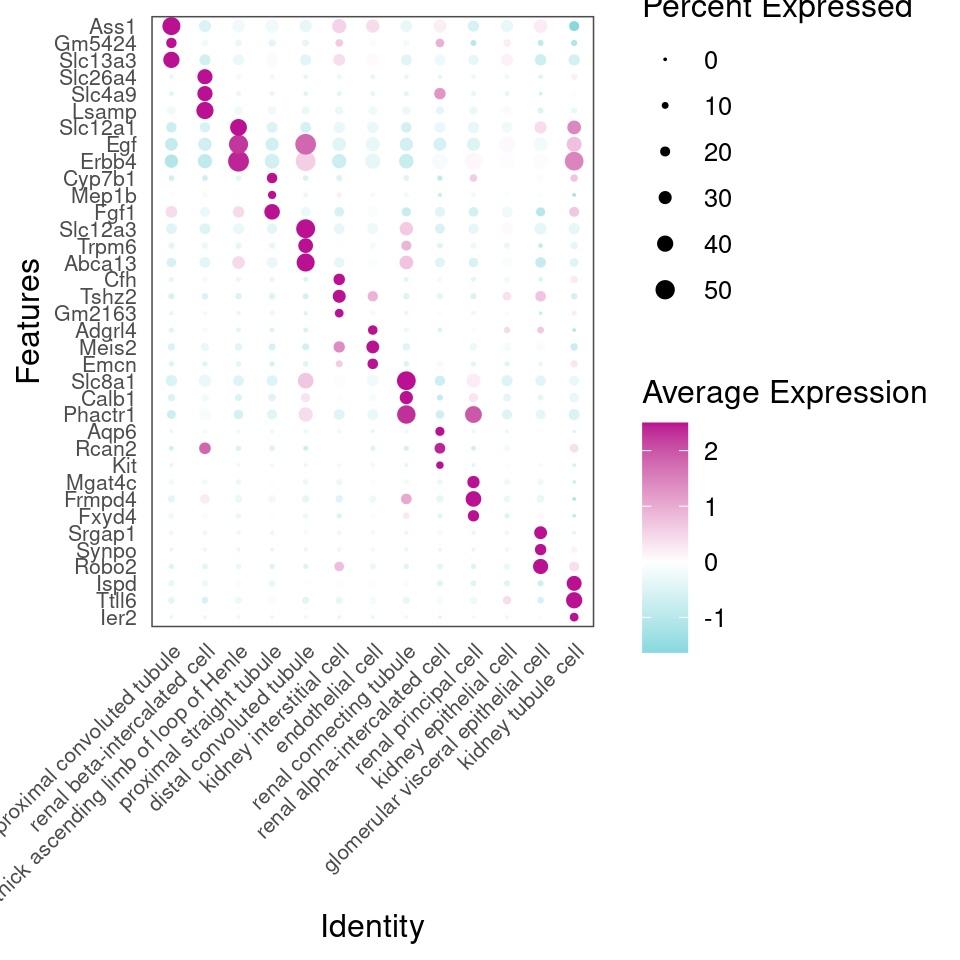

```r
(p <- use_dotplot(sc_kidney,features = rev(frame.seurat.p$gene), colors.gradient = c("#13c4cd","#ffffff","#b91192"),dot.scale = 3))
```

## 3.3 The Specificity Level Measured by Ti Among Two Softwares

```r
frame.seurat <- frame.seurat[,c("cluster","gene")]
frame.seurat <- cal_spe(sc_kidney,ident.use = "cell_type__ontology_label",as.data.frame(frame.seurat))
frame.seurat %>% head()
```

```
##                        cluster    gene   pct.pos
## 1   proximal convoluted tubule    Ass1 0.7523093
## 2   proximal convoluted tubule  Gm5424 0.7615974
## 3   proximal convoluted tubule Slc13a3 0.8040142
## 4   proximal convoluted tubule   Glis1 0.7881795
## 5   proximal convoluted tubule  Cyp4b1 0.7400982
## 6 renal beta-intercalated cell Slc26a4 0.6527027
```

```r
frame.star <- subset(frame.star,frame.star$cluster %in% frame.seurat$cluster)
frame.star %>% head()
```

```
##                              cluster    gene   pct.pos
## Glis1     proximal convoluted tubule   Glis1 0.7881795
## Ces1f     proximal convoluted tubule   Ces1f 0.7004859
## Ass1      proximal convoluted tubule    Ass1 0.7523093
## Cyp2d12   proximal convoluted tubule Cyp2d12 0.7763566
## Cyp2j13   proximal convoluted tubule Cyp2j13 0.7847332
## Hmx2    renal beta-intercalated cell    Hmx2 0.8248588
```

```r
identical(frame.star$cluster,frame.seurat$cluster)
```

```
## [1] TRUE
```

```r
frame.pct.pos <- data.frame(cluster = frame.star$cluster,pct.star = frame.star$pct.pos,pct.seurat = frame.seurat$pct.pos)

#cal seurat.mean
frame.pct.pos$pct.seurat.mean <- rep(aggregate(pct.seurat ~ cluster, data = frame.pct.pos, FUN = mean)$pct.seurat,each = 5)

#divide seurat.mean to get star.adk and seurat.adj
frame.pct.pos$pct.seurat.adj <- frame.pct.pos$pct.seurat/frame.pct.pos$pct.seurat.mean
frame.pct.pos$pct.star.adj <- frame.pct.pos$pct.star/frame.pct.pos$pct.seurat.mean

#cal star.adj.mean to arrange the plot
frame.pct.pos$pct.star.adj.mean <- rep(aggregate(pct.star.adj ~ cluster, data = frame.pct.pos, FUN = mean)$pct.star.adj,each = 5)

#arrange
frame.pct.pos <- arrange(frame.pct.pos,desc(pct.star.adj.mean))
frame.pct.pos$cluster <- factor(frame.pct.pos$cluster,levels = unique(frame.pct.pos$cluster))

p <- c()
foldchange <- c()
for (i in unique(frame.pct.pos$cluster)){
  mat <- subset(frame.pct.pos,cluster == i)
  t1 <- mat$pct.star
  t2 <- mat$pct.seurat
  p.i <- t.test(t1,t2)$p.value
  foldchange.i <- mean(mat$pct.star)/mean(mat$pct.seurat)

  foldchange <- append(foldchange,foldchange.i)
  p <- append(p,p.i)
}
frame.pct.pos.stat <- data.frame(cluster = unique(frame.pct.pos$cluster),p = p, foldchange = foldchange)
```

visulize

```r
mat.use <- reshape2::melt(frame.pct.pos[,c(1,5,6)])
```

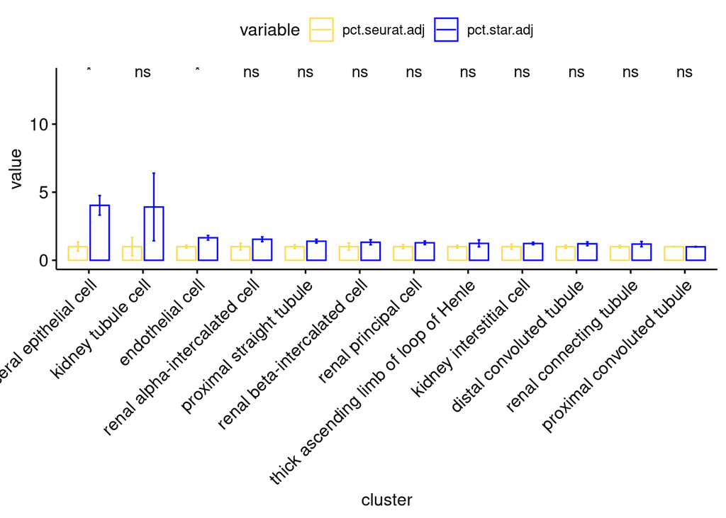

```r
(p <- ggbarplot(mat.use, x = "cluster", y = "value", add = c("mean_se"),color = "variable",fill = "white",palette = c("#fcdc57","blue"),
          position = position_dodge(0.8)) + stat_compare_means(aes(group = variable), label = "p.signif") + theme(axis.text.x = element_text(angle = 45,hjust = 1)))
```